# RPE for each species

Elena Quintero

```r
#Call requiered packages
library(readr)
library(effect.lndscp)
library(devtools)
```

```r
library(ggplot2)
library(ggrepel)
```

Problems to solve: - Error bars out of graph - Name of isolines - move further right - Choose apropriate visualization when too many species points: - Use numbers and legend - Change to shorter names - Grouping for plant families - Avoid clustering - ggrepel options

# CRACIDAE

Done for Penelope and Aburria together as there is few data.

```r
#Import data
Cracidae <- read_delim("Cracidae.csv", ";", escape_double = FALSE,
                      col_types = cols(plant = col_factor(levels = c()),
                      plant_family = col_factor(levels = c()),
                      species = col_factor(levels = c())), trim_ws = TRUE)
str(Cracidae)
```

[output not shown]

[output cut: 14 more lines]

[output not shown]

```r
names(Cracidae)
```

```
##  [1] "species"         "plant"           "plant_family"
##  [4] "QTY"             "QTY_SD"          "energy_fruit"
##  [7] "QLY"             "QLY_SD"          "QTY_SE"
## [10] "QLY_SE"          "fruit_visit"     "fruit_visit_SD"
## [13] "energy_visit"    "energy_visit_SD" "fruit_visit_SE"
## [16] "energy_visit_SE" "TE"              "TE2"
```

RPE here is based on: QTY component (visit_freq*fruits_visit) and QLY (fruit energy). Therefore there is no variation in Y axis

```r
#RPE for Cracids
Cracid <- subset(Cracidae, Cracidae$QTY > 0) #Select rows for which we have data
Cracid
```

```
## # A tibble: 4 × 18
##              species              plant  plant_family      QTY   QTY_SD
##               <fctr>             <fctr>        <fctr>    <dbl>    <dbl>
## 1 Aburria jacutintga Cecropia glaziovii     Urticacea 0.017333 0.021455
## 2 Aburria jacutintga     Euterpe edulis     Arecaceae 0.624750 0.634376
## 3 Aburria jacutintga    Virola bicuhyba Myristicaceae 0.077000       NA
## 4   Penelope obscura     Euterpe edulis     Arecaceae 0.078200 0.048319
## # ... with 13 more variables: energy_fruit <dbl>, QLY <dbl>, QLY_SD <dbl>,
## #   QTY_SE <dbl>, QLY_SE <dbl>, fruit_visit <dbl>, fruit_visit_SD <dbl>,
## #   energy_visit <dbl>, energy_visit_SD <dbl>, fruit_visit_SE <dbl>,
## #   energy_visit_SE <dbl>, TE <dbl>, TE2 <dbl>
```

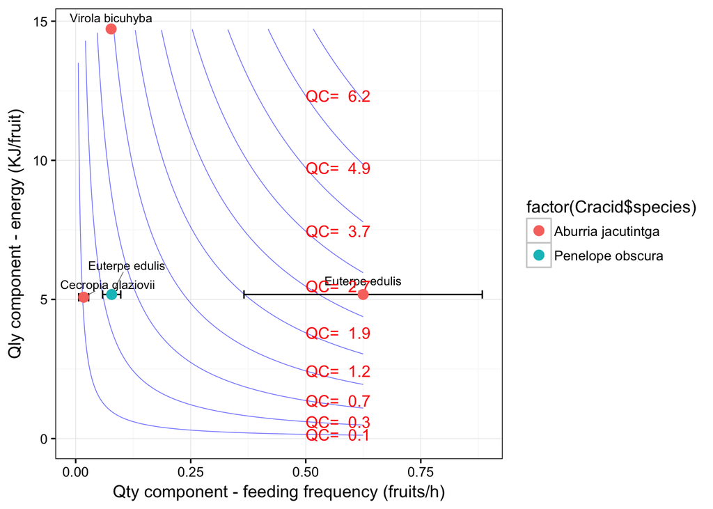

```r
RPE2_Cracidae <- effectiveness_plot(Cracid$QTY, Cracid$energy_fruit, ,
                                    Cracid$plant, 10,
                                    myxlab= "Qty component - feeding frequency (fruits/h)",
                                    myylab= "Qly component - energy (KJ/fruit)")
#Include SE bars and colors for each species
RPE2_Cracidae + geom_errorbarh(aes(xmin = Cracid$QTY - Cracid$QTY_SE,xmax = Cracid$QTY + Cracid$QTY_SE), height=0.3)+
                geom_point(aes(colour = factor(Cracid$species)), size=3)
```

Using estimated number of fruits/visit from regression. Nectandra and Phytolacca sp get very high estimates as they are small fruits - probably unrealistic

```r
#RPE for Cracids using fruits/visit and energy/fruit
#Overcomming missing data for visitation frequency and from estimated fruits/visit
Cracidae
```

```
## # A tibble: 16 × 18
##               species                   plant   plant_family      QTY
##                <fctr>                  <fctr>         <fctr>    <dbl>
## 1  Aburria jacutintga      Cecropia glaziovii      Urticacea 0.017333
## 2  Aburria jacutintga Citharexylum myrianthum    Verbenaceae       NA
## 3  Aburria jacutintga       Cordia silvestris   Boraginaceae       NA
## 4  Aburria jacutintga    Cryptocarya moschata      Lauraceae       NA
## 5  Aburria jacutintga    Cupania oblongifolia    Sapindaceae       NA
## 6  Aburria jacutintga          Euterpe edulis      Arecaceae 0.624750
## 7  Aburria jacutintga           Ficus enormis       Moraceae       NA
## 8  Aburria jacutintga  Nectandra megapotamica      Lauraceae       NA
## 9  Aburria jacutintga       Phytolacca dioica Phytolaccaceae       NA
## 10 Aburria jacutintga         Quiina glazovii     Quiinaceae       NA
## 11 Aburria jacutintga         Virola bicuhyba  Myristicaceae 0.077000
## 12 Aburria jacutintga         Virola oleifera  Myristicaceae       NA
## 13   Penelope obscura          Euterpe edulis      Arecaceae 0.078200
## 14   Penelope obscura       Myrcia pubipetala      Myrtaceae       NA
## 15   Penelope obscura  Nectandra megapotamica      Lauraceae       NA
## 16   Penelope obscura         Quiina glazovii     Quiinaceae       NA
## # ... with 14 more variables: QTY_SD <dbl>, energy_fruit <dbl>, QLY <dbl>,
## #   QLY_SD <dbl>, QTY_SE <dbl>, QLY_SE <dbl>, fruit_visit <dbl>,
## #   fruit_visit_SD <dbl>, energy_visit <dbl>, energy_visit_SD <dbl>,
## #   fruit_visit_SE <dbl>, energy_visit_SE <dbl>, TE <dbl>, TE2 <dbl>
```

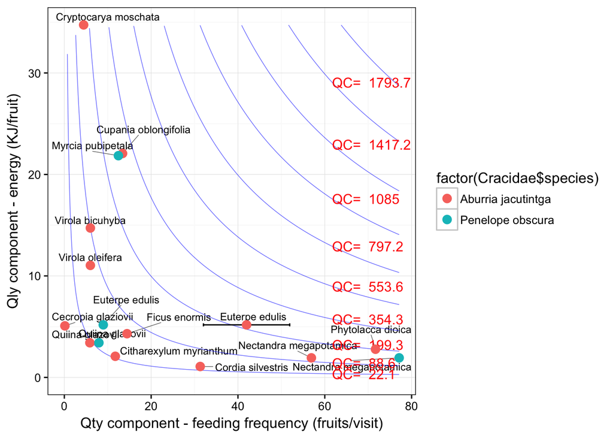

```r
RPE_Cracidae <- effectiveness_plot(Cracidae$fruit_visit, Cracidae$energy_fruit, ,
                                   Cracidae$plant, 10,
                                   myxlab= "Qty component - feeding frequency (fruits/visit)",
                                   myylab= "Qly component - energy (KJ/fruit)")
#Include SE bars and colors for each species
RPE_Cracidae + geom_errorbarh(aes(xmin = Cracidae$fruit_visit - Cracidae$fruit_visit_SE, xmax = Cracidae$fruit_visit +
              Cracidae$fruit_visit_SE), height=0.3)+
              geom_point(aes(colour = factor(Cracidae$species)), size=3)
```

To add Y axis variability in this RPE, the QLY component is (fruit specific energy*PDM/FFRM*frug_capacity/fruits_visit). Problem: hard to explain this intraespecific variability

```r
Cracidae
```

```
## # A tibble: 16 × 18
##               species                   plant   plant_family      QTY
##                <fctr>                  <fctr>         <fctr>    <dbl>
## 1  Aburria jacutintga      Cecropia glaziovii      Urticacea 0.017333
## 2  Aburria jacutintga Citharexylum myrianthum    Verbenaceae       NA
## 3  Aburria jacutintga       Cordia silvestris   Boraginaceae       NA
## 4  Aburria jacutintga    Cryptocarya moschata      Lauraceae       NA
## 5  Aburria jacutintga    Cupania oblongifolia    Sapindaceae       NA
## 6  Aburria jacutintga          Euterpe edulis      Arecaceae 0.624750
## 7  Aburria jacutintga           Ficus enormis       Moraceae       NA
## 8  Aburria jacutintga  Nectandra megapotamica      Lauraceae       NA
## 9  Aburria jacutintga       Phytolacca dioica Phytolaccaceae       NA
## 10 Aburria jacutintga         Quiina glazovii     Quiinaceae       NA
## 11 Aburria jacutintga         Virola bicuhyba  Myristicaceae 0.077000
## 12 Aburria jacutintga         Virola oleifera  Myristicaceae       NA
## 13   Penelope obscura          Euterpe edulis      Arecaceae 0.078200
## 14   Penelope obscura       Myrcia pubipetala      Myrtaceae       NA
## 15   Penelope obscura  Nectandra megapotamica      Lauraceae       NA
## 16   Penelope obscura         Quiina glazovii     Quiinaceae       NA
## # ... with 14 more variables: QTY_SD <dbl>, energy_fruit <dbl>, QLY <dbl>,
## #   QLY_SD <dbl>, QTY_SE <dbl>, QLY_SE <dbl>, fruit_visit <dbl>,
## #   fruit_visit_SD <dbl>, energy_visit <dbl>, energy_visit_SD <dbl>,
## #   fruit_visit_SE <dbl>, energy_visit_SE <dbl>, TE <dbl>, TE2 <dbl>
```

```
## geom_path: Each group consists of only one observation. Do you need to
## adjust the group aesthetic?
```

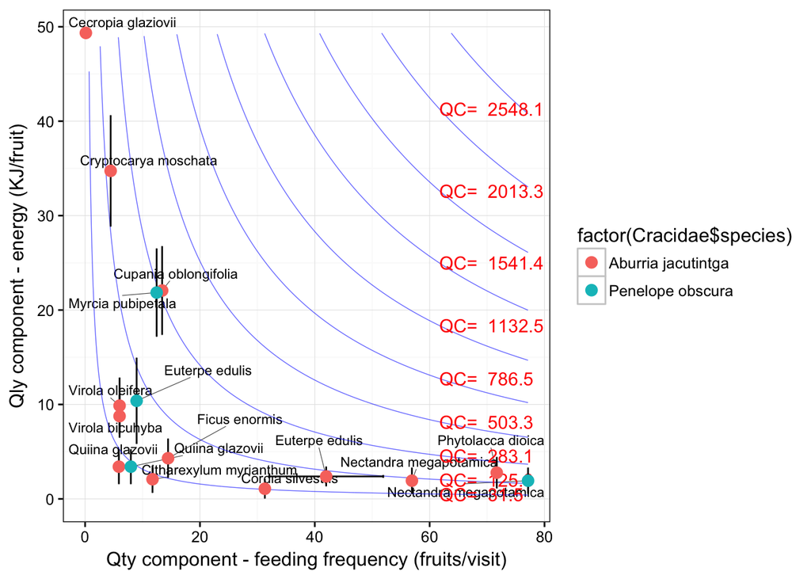

```r
RPE_Cracidae2 <- effectiveness_plot(Cracidae$fruit_visit, Cracidae$QLY, ,
                                   Cracidae$plant, 10,
                                   myxlab= "Qty component - feeding frequency (fruits/visit)",
                                   myylab= "Qly component - energy (KJ/fruit)")
#Include SE bars and colors for each species
RPE_Cracidae2 + geom_errorbar(aes(ymin= Cracidae$QLY - Cracidae$QLY_SE, ymax=Cracidae$QLY + Cracidae$QLY_SE), width=.02)+
              geom_errorbarh(aes(xmin = Cracidae$fruit_visit - Cracidae$fruit_visit_SE, xmax = Cracidae$fruit_visit +
              Cracidae$fruit_visit_SE),height=0.3)+
              geom_point(aes(colour = factor(Cracidae$species)), size=3)
```

Issue: RPE with QLY variability and without variability is different! - specially for cases as Cecropia

# RAMPHASTIDAE

```r
#Import data
Toucans <- read_delim("Toucans.csv", ";", escape_double = FALSE,
                    col_types = cols(plant = col_factor(levels = c()),
                    plant_family = col_factor(levels = c()),
                    species = col_factor(levels = c())), trim_ws = TRUE)

#Subset for each toucan species
Baillonus <- subset(Toucans, species == "Baillonius bailloni")
R_dicol <- subset(Toucans, species == "Ramphastos dicolorus")
R_vitel <- subset(Toucans, species == "Ramphastos vitellinus")
Selenidera <- subset(Toucans, species == "Selenidera maculirostris")
```

```
## geom_path: Each group consists of only one observation. Do you need to
## adjust the group aesthetic?
```

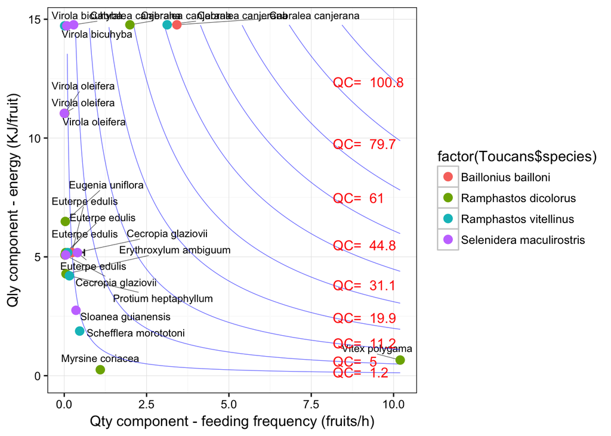

```r
#RPE for all Toucans together
RPE_toucans <- effectiveness_plot(Toucans$QTY, Toucans$energy_fruit,,
                Toucans$plant, 10,
                myxlab= "Qty component - feeding frequency (fruits/h)",
                myylab= "Qly component - energy (KJ/fruit)")
RPE_toucans +   geom_errorbarh(aes(xmin = Toucans$QTY - Toucans$QTY_SE, xmax = Toucans$QTY + Toucans$QTY_SE), height=0.3)+
                geom_point(aes(colour = factor(Toucans$species)), size=3)
```

## Baillonius bailloni

Different RPEs if variation in QLY or not.

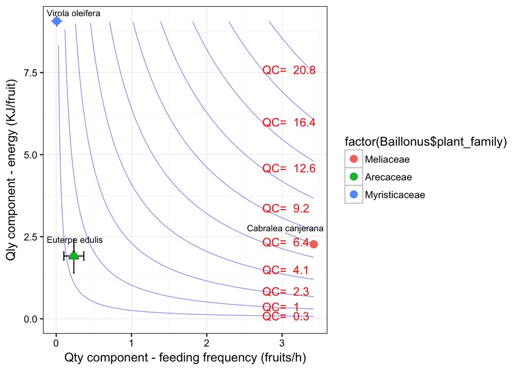

```r
#RPE landscape for Baillonius bailloni with QLY variation
RPE_Baillonus <- effectiveness_plot(Baillonus$QTY, Baillonus$QLY,
                Baillonus$plant_family,
                Baillonus$plant, 10,
                myxlab= "Qty component - feeding frequency (fruits/h)",
                myylab= "Qly component - energy (KJ/fruit)")
RPE_Baillonus + geom_errorbar(aes(ymin= Baillonus$QLY - Baillonus$QLY_SE,ymax=Baillonus$QLY + Baillonus$QLY_SE),width=.02) +
                geom_errorbarh(aes(xmin = Baillonus$QTY - Baillonus$QTY_SE, xmax = Baillonus$QTY + Baillonus$QTY_SE), height=0.3)+
                geom_point(aes(colour = factor(Baillonus$plant_family)), size=3)
```

[figure not shown]

```r
#RPE landscape for Baillonius bailloni without QLY variation
RPE_Baillonus2 <- effectiveness_plot(Baillonus$QTY, Baillonus$energy_fruit,
                  Baillonus$plant_family, Baillonus$plant, 10,
                  myxlab= "Qty component - feeding frequency (fruits/h)",
                  myylab= "myylab(KJ/fruit)")
RPE_Baillonus2 + geom_errorbarh(aes(xmin = Baillonus$QTY - Baillonus$QTY_SE, xmax = Baillonus$QTY + Baillonus$QTY_SE),height=0.3)+
                  geom_point(aes(colour = factor(Baillonus$plant_family)), size=3)
```

## Ramphastos dicolorus

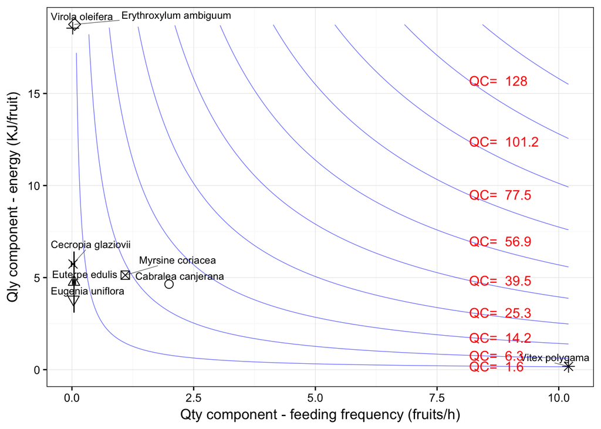

```r
RPE_R_dicol <- effectiveness_plot(R_dicol$QTY, R_dicol$QLY, R_dicol$plant_family,
                R_dicol$plant, 10,
                myxlab= "Qty component - feeding frequency (fruits/h)",
                myylab= "Qly component - energy (KJ/fruit)")
RPE_R_dicol + geom_errorbar(aes(ymin= R_dicol$QLY - R_dicol$QLY_SD, ymax=R_dicol$QLY+ R_dicol$QLY_SD), width=.02) +
              geom_errorbarh(aes(xmin = R_dicol$QTY - R_dicol$QTY_SD,xmax = R_dicol$QTY + R_dicol$QTY_SD), height=0.3)
```

RPE change with digestibility values

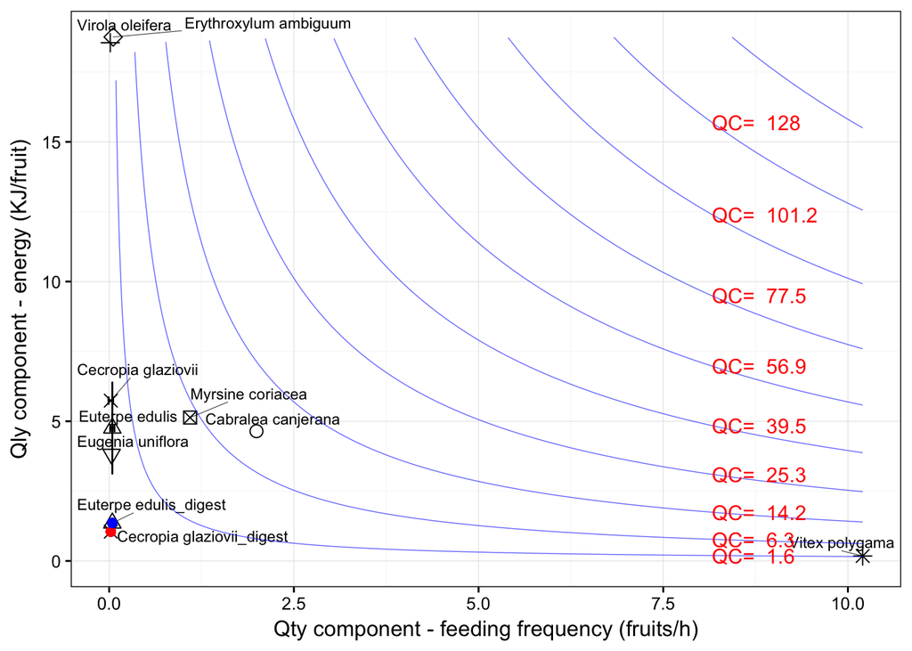

```r
#Data
Toucans2 <- read_delim("Toucans_digest.csv", ";", escape_double = FALSE,
                    col_types = cols(plant = col_factor(levels = c()),
                    plant_family = col_factor(levels = c()),
                    species = col_factor(levels = c())), trim_ws = TRUE)
#INCLUDING DIGESTIBILITY VALUES
R_dicol2 <- subset(Toucans2, species == "Ramphastos dicolorus")
RPE_R_dicol_digest <- effectiveness_plot(R_dicol2$QTY, R_dicol2$QLY, R_dicol2$plant_family,
                R_dicol2$plant, 10,
                myxlab= "Qty component - feeding frequency (fruits/h)",
                myylab= "Qly component - energy (KJ/fruit)")
RPE_R_dicol_digest + geom_errorbar(aes(ymin= R_dicol2$QLY - R_dicol2$QLY_SD, ymax=R_dicol2$QLY+ R_dicol2$QLY_SD), width=.02) +
              geom_errorbarh(aes(xmin = R_dicol2$QTY - R_dicol2$QTY_SD,xmax = R_dicol2$QTY + R_dicol2$QTY_SD), height=0.3)+
              geom_point(aes(x=R_dicol2$QTY[2],y=R_dicol2$QLY[2]), colour="red", size=2)+
              geom_point(aes(x=R_dicol2$QTY[6],y=R_dicol2$QLY[6]), colour="blue", size=2)
```

When including digestibility the points go further down in the quality scale